# Challenger O-Ring Data – Logistic Regression

#### Background

[Watch the Introductory Movie](http://www.history.com/topics/challenger-disaster/videos/engineering-disasters---challenger)

|  | Temp | Pres | Fail | n | Erosion | BlowBy | Damage | Date |
| --- | --- | --- | --- | --- | --- | --- | --- | --- |
| 1 | 66 | 50 | 0 | 6 | 0 | 0 | 0 | 4/12/81 |
| 2 | 70 | 50 | 1 | 6 | 1 | 0 | 4 | 11/12/81 |
| 3 | 69 | 50 | 0 | 6 | 0 | 0 | 0 | 3/22/82 |
| 5 | 68 | 50 | 0 | 6 | 0 | 0 | 0 | 11/11/82 |
| 6 | 67 | 50 | 0 | 6 | 0 | 0 | 0 | 4/4/83 |
| 7 | 72 | 50 | 0 | 6 | 0 | 0 | 0 | 6/18/83 |

As described in the video, it was known that the o-rings could fail when the tempurature was below 53° F. It then stated that “Nasa had already launched shuttles below 53° and gotten away with it.” This second statement is actually false. The lowest temperature of any of the 23 prior launches (before the Challenger explosion) was 53° F [[view source]](http://www.ics.uci.edu/~staceyah/111-202/handouts/Dalal_etal_1989-Challenger.pdf). The “evidence” that the o-rings could fail below 53° was based on a simple conclusion that since the launch at 53° experienced two o-ring failures, it seemed unwise to launch below that temperature. The statement that NASA had launched previously with o-ring failures occurring, but the launch still being successful was true, but all launches had a temperature of at least 53° F. Thus, whether or not temperature was the root cause of the failures was debatable.

#### Logistic Model

To model the probability of the o-rings failing at various temperatures, we could apply the logistic regression model
$$P(Y_i = 1|x_i) = \frac{e^{\beta_0+\beta_1 x_i}}{1+e^{\beta_0 + \beta_1 x_i}} = \pi_i$$
where for observation $i$:

- $Y_i = 1$ denotes at least one o-ring failing for a given launch,
- $Y_i=0$ denotes no o-rings failing (successful launch), and
- $x_i$ denotes the outside temperature in degrees farenheit at the time of the launch.

Note that if $\beta_1$ is zero in the above model, then $x_i$ (temperature) provides no insight about the probability of a failed O-ring. Thus, we could test the hypothesis that

$$H_0: \beta_1 = 0 \\
H_a: \beta_1 \neq 0$$

#### Fitting the Model

To obtain estimates of the coefficients $\beta_0$ and $\beta_1$ for the `challeng` data, we apply the following R code.

```r
chall.glm <- glm(Fail>0 ~ Temp, data=challeng, family=binomial)
summary(chall.glm)
```

```
##
## Call:
## glm(formula = Fail > 0 ~ Temp, family = binomial, data = challeng)
##
## Deviance Residuals:
##     Min       1Q   Median       3Q      Max
## -1.0611  -0.7613  -0.3783   0.4524   2.2175
##
## Coefficients:
##             Estimate Std. Error z value Pr(>|z|)
## (Intercept)  15.0429     7.3786   2.039   0.0415 *
## Temp         -0.2322     0.1082  -2.145   0.0320 *
## ---
## Signif. codes:  0 '***' 0.001 '**' 0.01 '*' 0.05 '.' 0.1 ' ' 1
##
## (Dispersion parameter for binomial family taken to be 1)
##
##     Null deviance: 28.267  on 22  degrees of freedom
## Residual deviance: 20.315  on 21  degrees of freedom
## AIC: 24.315
##
## Number of Fisher Scoring iterations: 5
```

Thus the estimated model for $\pi_i$ is given by
$$P(Y_i = 1|x_i) \approx \frac{e^{15.043-0.232 x_i}}{1+e^{15.043 - 0.232 x_i}} = \hat{\pi}_i$$
where $b_0 = 15.043$ is the value of the `(Intercept)` which estimates $\beta_0$ and $b_1 = -0.232$ is the value of `Temp` which estimates $\beta_1$.

Importantly, the $p$-value for the test of `Temp` shows a significant result $(p = 0.0320)$ giving sufficient evidence to conclude that $\beta_1 \neq 0$, which allows us to conclude that temperature effects the probability of an O-ring failure.

#### Visualizing the Model

To visualize this simple logistic regression we could make the following plot.

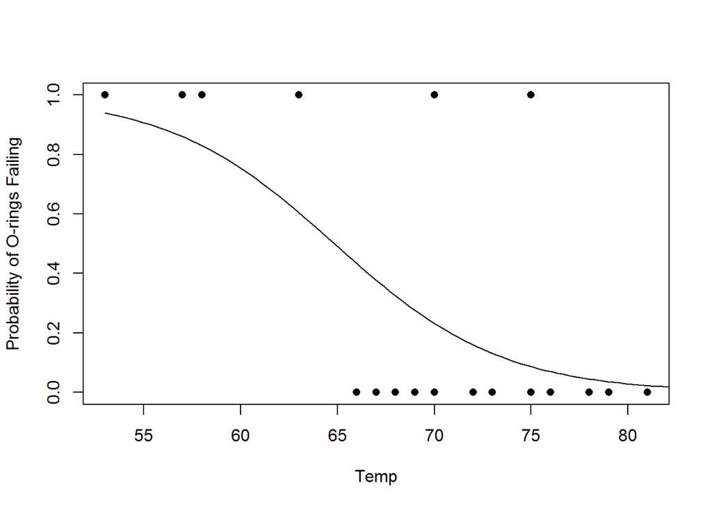

```r
plot( Fail>0 ~ Temp, data=challeng, main="", ylab='Probability of O-rings Failing', pch=16)
curve(exp(15.043-0.232*x)/(1+exp(15.043-0.232*x)), from=53, to=85, add=TRUE)
```

#### Diagnosing the Model

To demonstrate that the logistic regression is a good fit to these data we apply the Hosmer-Lemeshow goodness of fit test (since there are only a couple repeated $x$-values) from the `library(ResourceSelection)`.

```r
hoslem.test(chall.glm$y, chall.glm$fitted, g=6)
```

```
##
##  Hosmer and Lemeshow goodness of fit (GOF) test
##
## data:  chall.glm$y, chall.glm$fitted
## X-squared = 7.4118, df = 4, p-value = 0.1157
```

```r
# Note: doesn't give a p-value for g >= 7, default is g=10.
# Larger g is usually better than smaller g.
```

Recall that the null hypothesis is that the logistic regression is a good fit for the data, thus we conclude the null, and claim that the logistic regression is appropriate.

#### Interpreting the Model

Since the temperature being zero is not really realistic for this model, the value of $e^{b_0}$ is not interpretable. However, the value of $e^{b_1} = e^{-0.232} \approx 0.79$ shows that the odds of the o-rings failing for a given launch decreases by a factor of 0.79 for every 1° F increase in temperature. (Note that this implies that every 1° F decrease in temperature increases the odds of a failed o-ring by a factor of $e^{0.232} \approx 1.26$.) The Challenger shuttle was launched at a tempurature of 31° F. By waiting until 53° F, the odds of failure would have been decreased by a factor of $e^{-0.232(53-31)}\approx 0.006$. Note that for a temperature of 31° F our model puts the probability of a failure at
$$P(Y_i = 1|x_i) \approx \frac{e^{15.043-0.232\cdot 31}}{1+e^{15.043 - 0.232 \cdot 31}} = \hat{\pi}_i$$
which, using R to do this calculation we get $\hat{\pi_i} \approx$

```r
predict(chall.glm, data.frame(Temp=31), type='response')
```

```
##         1
## 0.9996088
```